# CSC 250 - Final Project: Theory of Stable Allocations and Market Design

Ha Cao, Hening Zheng

5/6/2018

## Introduction

Resource allocation has always been a strongly focused area of study for economists and mathematicians because the resources of a society are in limited supply, whereas human wants are usually unlimited, and because any given resource can have many alternative uses.[^1] Traditional economic analysis studies markets where prices adjust so that supply equals demand, but there are cases where prices cannot be used to allocate resources, but an allocation still has to be made. So how do such allocating processes actually work and when is the outcome efficient?[^2]

These questions lead us to the topic of **stable allocation** a.k.a. **stable matching**. Given a group, or several groups, of agents, each having a preference list over the agents with whom they may be matched, an **instability** (also called an **unstable pair**) is a pair of agents who prefer each other to their assigned partners. A **stable matching** is a solution which provides a matching with no instability/unstable pair.

In 1962, David Gale and Lloyd Shapley presented an algorithm, later referred to as the *Gale-Shapley algorithm*, that can output a stable matching as long as the couples in the given list of agents are not taken into consideration (i.e. each agent is treated as an independent indiviual). The algorithm was first developed to solve the marriage problem for an equal number of men and women. Over the years, many variants of this algorithm have been developed to solve similar problems with some different conditions.[^3]

David Gale and Lloyd Shapley made the early theoretical contributions, which were unexpectedly adopted two decades later when Alvin Roth investigated the market for U.S. doctors. Alvin’s findings generated further analytical developments, as well as practical design of market institutions.[^4]

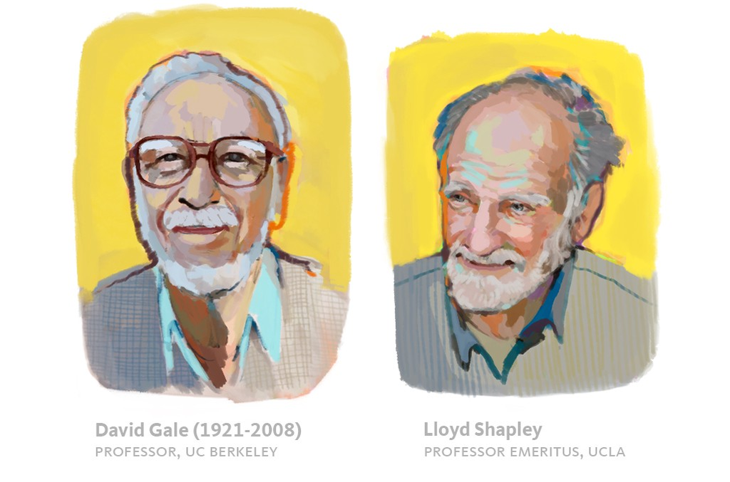

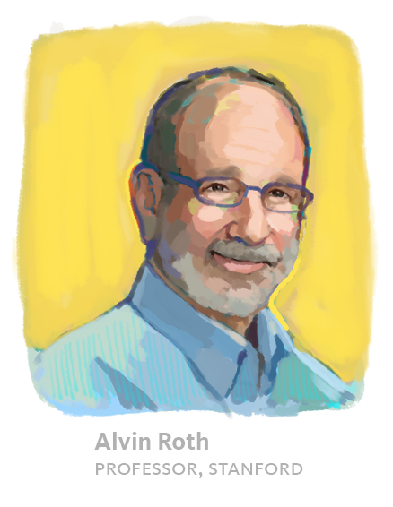

## Stable Matching with the Gale-Shapley Algorithm[^5]

### Description of the Algorithm

Detailed description of the Gale-Shapley algorithm is as follows:

The Gale–Shapley algorithm involves a number of “rounds” (or “iterations”):

- In the first round, first a) each unengaged man proposes to the woman he prefers most, and then b) each woman replies “maybe” to her suitor she most prefers and “no” to all other suitors. She is then provisionally “engaged” to the suitor she most prefers so far, and that suitor is likewise provisionally engaged to her.
- In each subsequent round, first a) each unengaged man proposes to the most-preferred woman to whom he has not yet proposed (regardless of whether the woman is already engaged), and then b) each woman replies “maybe” if she is currently not engaged or if she prefers this guy over her current provisional partner (in this case, she rejects her current provisional partner who becomes unengaged). The provisional nature of engagements preserves the right of an already-engaged woman to “trade up” (and, in the process, to “jilt” her until-then partner).
- This process is repeated until everyone is engaged.

The runtime complexity of this algorithm is $O(n^{2})$ where $n$ is number of men or women.

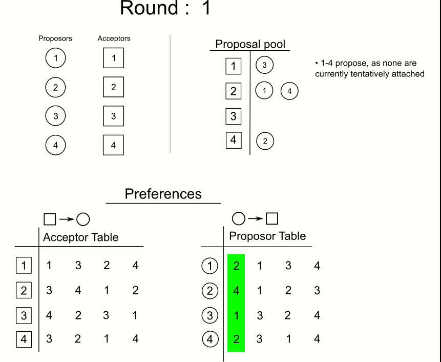

Pseudo-codes for the algorithm are as follows:

```
FUNCTION stableMatching {
    INITIALIZE all m ∈ M and w ∈ W to free
    WHILE ∃ free man m who still has a woman w to propose to {
       w = first woman on m’s list to whom m has not yet proposed
       IF w is free
         (m, w) become engaged
       ELSE some pair (m', w) already exists
         IF w prefers m to m'
            m' becomes free
           (m, w) become engaged
         ELSE
           (m', w) remain engaged
    }
}
```

### Discussion of the Algorithm

This algorithm guarantees that:

**Everyone gets married**

At the end, there cannot be a man and a woman both unengaged, as he must have proposed to her at some point (since a man will eventually propose to everyone, if necessary) and, being proposed to, she would necessarily be engaged (to someone) thereafter.

**The marriages are stable**

Let Alice and Bob both be engaged, but not to each other. Upon completion of the algorithm, it is not possible for both Alice and Bob to prefer each other over their current partners. If Bob prefers Alice to his current partner, he must have proposed to Alice before he proposed to his current partner. If Alice accepted his proposal, yet is not married to him at the end, she must have dumped him for someone she likes more, and therefore doesn’t like Bob more than her current partner. If Alice rejected his proposal, she was already with someone she liked more than Bob.

While the solution is stable, it is not necessarily optimal from all individuals’ points of view. The traditional form of the algorithm is optimal for the initiator of the proposals and the stable, suitor-optimal solution may or may not be optimal for the reviewer of the proposals. For example, in the marriage problem, if women were given the right to propose, they would have an advantage over men in choosing their partners, because some women would wind up with men they like better (their best possible option) and no women would be worse off than if men were given the right to propose.[^6]

## Stable Matching with Couples[^7]

An instance of the hospitals/residents problem with couples is not guaranteed to have a stable matching. Deciding if a stable matching exists for a given instance has been proved by Eytan Ronn to be $NP$-complete.

### Formal Definition of the Problem

1. Input:
   - $L$, a list of preference lists
   - $H$, a set of hospitals, each hospital $h$ having a preference list $L_h$ over the residents in $R$
   - $R$, a set of applicants (including couples), each applicant $r$ having a preference list $L_r$ over the hospitals in $H$
2. Goal: decide if there exists a stable matching
3. $HRC$ = { $H, R, L$ | there exists a stable matching from $H$ to $R$ with accordance to the preference lists $L$, where $R$ contains couples }

### Proof idea for $HRC \in NP$

In his paper, Ronn briefly went over the idea for proving $HRC$’s membership in $NP$, which remains a bit unclear to us. Thus, we decide to prove $HRC \in NP$ by ourselves:

To prove that $HRC$ is in $NP$, we can show that there is verifier for $HRC$ running in time polynomial in the size of H, the set of hospitals (of size $n$), and, $R$, the set of residents (of size $m$).  
The certificate for this verifier is a matching $M$ from $H$ to $R$.

For each pair $(h,r)$ in the matching $M$, we go over each applicant $r'$ in whom $h$ prefers to $r$. For each of such $r'$, we check if $r'$ prefers $h$ to $h'$, the hospital they are currently matched to. If so, the matching is not stable, because $(h,r')$ is an instability/unstable pair.

We can formally define the verifier as the following:

“On input $\langle H, R, L, M\rangle$:

- for each pair $(h, r) \in M$: *(O(n))*
  - for each $r′$ where $L_{h,r′} < L_{h,r}$: *(O(m))*
    - if $L_{r',h} < L_{r',h'}$ where $(h′, r′) \in M$: REJECT *(O(1))*
- ACCEPT”

Since we have to go over at most all the hospitals, which is $O(n)$, and for each hospital, we have to check at most $m-1$ residents, which is $O(m)$, this verifier runs in $O(nm)$, which is in polynomial time. Thus, we know that $HRC$ is in $NP$.

### Proof idea for $HRC$ is $NP$-hard

1. Roommate Problem with Ties:

To prove that $HRC$ is $NP$-hard, Ronn first proved that $RWT$ is NP-complete. We can formally define the problem and the language as the following:

- Input:
  - $L$, a list of preference lists
  - $S$, a single set of $n$ (an even number) students, each student $i$ having a preference list $L_i$ over the other $n-1$ students, in which preferences can be tied
- Goal: decide if there is a stable matching, in other words, a partition of this single set into $\frac{n}{2}$ pairs so that there is no instability
- $RWT$ = { $S,L$ | there exists a stable matching of $S$ with accordance to the preference lists $L$ }
2. $RWT$ is $NP$-complete

Ronn then proved that $RWT$ is $NP$-complete: the $NP$-membership was proven using a polynomial-time verifier similar to the one used for proving the $NP$-membership of $HRC$; the $NP$-hardness proof was based on a reduction to $3SAT$: $3SAT \leq_p RWT$, where $3SAT$ = { $\phi$ | $\phi$ is a satisfiable Boolean formula in $3CNF$ } and $3CNF$ (an “AND” of three “ORs”): $(x_1 \vee x_2 \vee x_3)\ \wedge \cdots \wedge\ (x_x \vee x_y \vee x_z)$.

## Real-life Applications

### National Resident Matching Program

The National Resident Matching Program is an example of successfully applying a variant of the Gale-Shapley algorithm to solve the **hospitals/residents problem**, a.k.a the **college admissions problem**. It is different from the stable marriage problem in that a hospital can take multiple residents, or a college can take an incoming class of more than one student. Algorithms to solve the hospitals/residents problem can be *hospital-oriented* (as the National Resident Matching Program (NRMP) before 1995) or *resident-oriented* (as NRMP since 1995). This problem was solved with an algorithm that was published in the same paper by Gale and Shapley as the algorithm that solved the stable marriage problem.[^8]

Pseudo-codes for the algorithm are as follows:[^9]

```
INITIALIZE M to empty matching.
WHILE (some hospital h is unmatched and hasn’t proposed to every student)
    s = first student on h’s list to whom h has not yet proposed.
    IF (s is unmatched)
        Add h–s to matching M.
    ELSE IF (s prefers h to current partner hʹ)
        Replace hʹ–s with h–s in matching M.
    ELSE
        s rejects h.
RETURN stable matching M.
```

[video not shown]

### Matching Students and High Schools[^10]

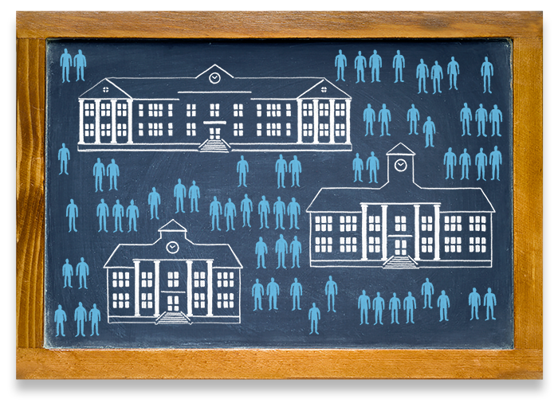

Up until 2003, applicants to New York City public high schools were asked to rank their five most preferred choices, after which these preference lists were sent to the schools. The schools then decided which students to admit, reject, or place on waiting lists. The process was repeated in two more rounds, and students who had not been assigned to any school after the third round were allocated through an administrative process. However, this did not provide the applicants with enough opportunities to list their preferences, and the schools did not have enough opportunities to make offers. As a result, about 30,000 students per year ended up at schools they had not listed. Moreover, the process gave rise to misrepresentation of preferences. Since schools were more likely to admit students who ranked them as their first choice, students unlikely to be admitted to their favorite school found it in their best interest to list a more realistic option as their first choice, while applicants who simply reported their true preferences suffered unnecessarily poor outcomes.

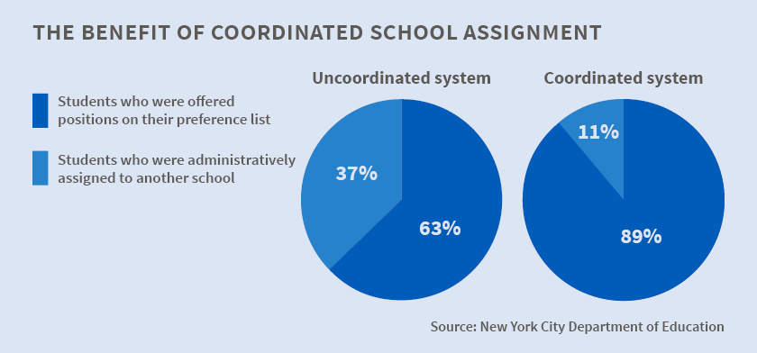

### Matching Kidneys with Patients[^11]

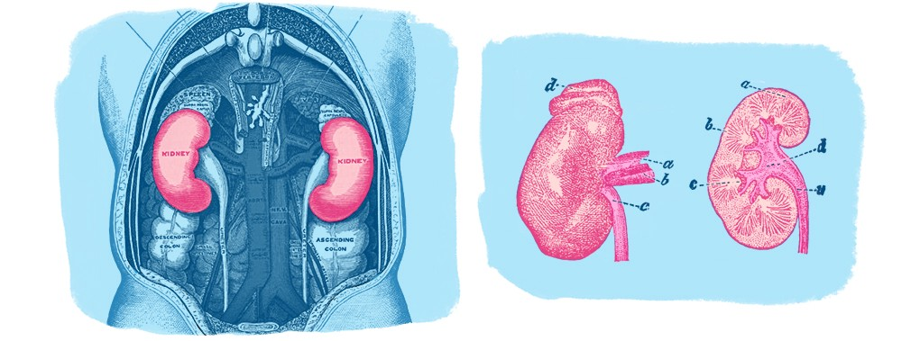

The matching settings described so far involve two sides that both make active decisions. Some real-world situations are one-sided, however, in the sense that the other side is entirely passive. A practical example is the matching of kidneys and other human organs to patients in need of a transplant. How can this be accomplished in an efficient way?

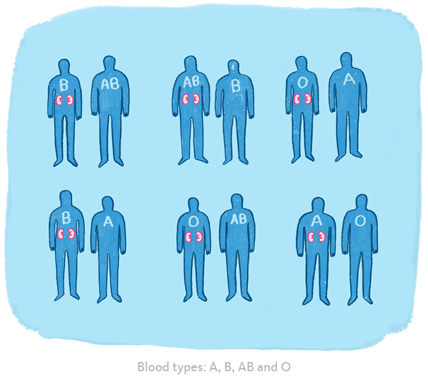

This problem was studied by Shapley and his colleagues, again in the abstract and based on the notion of stability. The proposed algorithm – the so-called top trading cycle – is in fact very simple. It is based on an initial allocation of objects and subsequent swapping. A challenge in the case of human organs is that some kidney-patient pairs may not be compatible and that complex multilateral swaps may be quite time consuming. Again, a combination of theory and experimental work has been used to com- pare different versions of top trading. As a result, increasingly complex chains of kidney donations are now adopted in a number of U.S. states.

### Matching with Prices[^12]

A striking feature of the above examples is that prices are not part of the process. Does the absence of a price mechanism in the basic Gale-Shapley algorithm limit its applicability? Not necessarily. Shapley and others examined extensions of the original model that allow for prices (salaries, in the market for doctors) to be part of the offers. Algorithms including prices work in much the same way and produce stable matches with broadly similar features. In fact, matching with prices is closely related to auctions, where objects are matched with buyers and where prices are decisive. Research that relates matching algorithms to auctions has recently generated interesting theoretical results, which appear to be applicable in practice. A case in point is the internet auction, in particular search engines that auction out space for advertisers. Companies in this business have benefited from insights inherent in the Gale-Shapley algorithms and have used top economists as experts in designing new auctions.

## Discussion

### Recognition

Lloyd Shapley and Alvin Roth received the 2012’s Nobel Prize in Economics for Lloyd Shapley’s abstract theory development in the 1960s, and Alvin Roth’s empirical work in the 1980s and ongoing efforts to find practical solutions to real-world problems. What is interesting is that Lloyd Shapley and Alvin Roth have worked independently of each other, but the success of their research is due to the combination of Shapley’s theoretical results with Roth’s insights into their practical value. In addition, although the Nobel Prize did not go to David Gale as Nobel Prizes are only awarded to people who are alive, David Gale deserves special credit for his enormous contribution to the development of algorithms that solve stable-matching problems.

[figure not shown]

### Key Take-aways

- We have learned that from the original algorithms that David and Lloyd developed, many variants of them have been created in order to solve similar stable-matching problems in various contexts/markets with slightly different conditions more efficiently.
- Problems in real life such as hospitals/residents matching, high-schools/students matching, kidneys/patients matching, which might look very different from each other on the surface, may actually share a lot in common underneath. Therefore, solving one problem might help solve other problems. This is what reductions are about! We have found this very interesting because when we thought of reductions before, we only thought about abstract mathematical theory and proofs, but now we have realized how reductions actually play out in reality.
- Even the hospitals/residents matching problem with couples has been proven to be $NP$-complete, we can still solve it with an acceptable accuracy and efficiency using the Gale-Shapley algorithm that is in $P$. Hence, sometimes, when we encounter problems that are provably hard, we may want to accept some “less-perfect” solutions that can solve most of the problems in polynomial time but ignore some edge cases that do not happen very often.

### Shortcomings and Areas for Future Improvement

One noticeable shortcoming of the Gale-Shapley algorithms is that they always favor the proposing side, which means the result is not optimal for all parties involved. However, as this is a mathematically inherent attribute of the algorithms, it would be impossible to change this shortcoming. Still, it is important to be aware of this shortcoming in order to give the proposing right to the appropriate side in the “trade”.

We find the Gale-Shapley algorithms very powerful in solving real-life stable-matching problems, and there are so many more situations that can be improved using these algorithms such as matching college students with courses so that every student meets their academic needs and takes the classes that they like and are suitable for their abilities so that they won’t drop, or matching singles on dating apps based on their preferences so that the successful rate is higher.

## Further Readings

We have found a very interesting [piece of writing on Medium](https://medium.com/@UofCalifornia/how-a-matchmaking-algorithm-saved-lives-2a65ac448698) about stable-matching algorithms and its real-life applications in a light-hearted and funny tone.

There is also a [game from UC Berkeley](http://mathsite.math.berkeley.edu/smp/smp.html) about stable marriage! Have fun!

## Personal Contributions to the Project

Ha: mostly worked on real-life applications of the algorithms and discussion of their significance

Hening: mostly worked on the proof for NP-completeness of the algorithm that decides whether there is a stable matching between hospitals and residents with couples

Ha and Hening: worked together on building the web page

[^1]: https://www.britannica.com/topic/allocation-of-resources
[^2]: https://www.nobelprize.org/nobel_prizes/economic-sciences/laureates/2012/popular-economicsciences2012.pdf
[^3]: https://en.wikipedia.org/wiki/Stable_marriage_problem
[^4]: https://www.nobelprize.org/nobel_prizes/economic-sciences/laureates/2012/popular-economicsciences2012.pdf
[^5]: https://en.wikipedia.org/wiki/Stable_marriage_problem
[^6]: https://www.nobelprize.org/nobel_prizes/economic-sciences/laureates/2012/popular-economicsciences2012.pdf
[^7]: https://pdfs.semanticscholar.org/8629/806af545d3828a9f70dcf7d379f7cfbd5d32.pdf
[^8]: https://en.wikipedia.org/wiki/Stable_marriage_problem
[^9]: https://www.cs.princeton.edu/~wayne/kleinberg-tardos/pdf/01StableMatching.pdf
[^10]: https://www.nobelprize.org/nobel_prizes/economic-sciences/laureates/2012/popular-economicsciences2012.pdf
[^11]: https://www.nobelprize.org/nobel_prizes/economic-sciences/laureates/2012/popular-economicsciences2012.pdf
[^12]: https://www.nobelprize.org/nobel_prizes/economic-sciences/laureates/2012/popular-economicsciences2012.pdf